# Torre Test

A prediction model of Job Type

Antonio Alvarez

18.05.2021

```r
library(readr)
library(dplyr)
library(ggplot2)
library(tidyr)
library(lubridate)
library(stringr)
library(purrr)
library(forcats)
library(tidytext)
library(recipes)
library(tensorflow)
library(embed)
library(reticulate)
library(caret)
library(rsample)
library(doParallel)
library(Metrics)
library(tfruns)
```

## Introduction

```r
# Read data and add order to certain vars by frequency
torre <- read_csv("data/reed_uk.csv") %>%
  mutate(city=fct_infreq(factor(str_to_title(city))), category=fct_infreq(factor(category)),
         post_date=mdy(post_date), month=month(post_date), weekday=wday(post_date))
```

## Exploratory Data Analysis

First, we need to start exploring it. This is a crucial step in every data analysis. Even more so in this case as no instructions or info about the date were given.

```r
glimpse(torre)
```

```
## Rows: 50,000
## Columns: 14
## $ category         <fct> catering jobs, law jobs, factory jobs, law jobs, fact~
## $ city             <fct> "Chudleigh", "Swindon", "Norfolk", "Hurstpierpoint", ~
## $ company_name     <chr> "Haulfryn Group", "Reed", "Swanstaff Recruitment Ltd"~
## $ geo              <chr> "uk", "uk", "uk", "uk", "uk", "uk", "uk", "uk", "uk",~
## $ job_board        <chr> "reed", "reed", "reed", "reed", "reed", "reed", "reed~
## $ job_description  <chr> "Apply now New opportunity not to be missed! Haulfryn~
## $ job_requirements <chr> NA, NA, NA, "Required skills Admin Case Management Co~
## $ job_title        <chr> "Commis Chef", "Corporate Legal Secretary", "Warehous~
## $ job_type         <chr> "Permanent, full-time", "Permanent, full-time", "Perm~
## $ post_date        <date> 2018-03-12, 2018-03-08, 2018-02-27, 2018-02-21, 2018~
## $ salary_offered   <chr> "£18,323 per annum", "£18,000 - £22,000 per annum", "~
## $ state            <chr> "Devon", "Wiltshire", "East Anglia", "West Sussex", "~
## $ month            <dbl> 3, 3, 2, 2, 3, 3, 2, 3, 2, 3, 3, 3, 3, 2, 3, 3, 3, 3,~
## $ weekday          <dbl> 2, 5, 3, 4, 5, 2, 4, 6, 4, 2, 2, 2, 3, 4, 4, 2, 4, 6,~
```

From a first glance, it is clear that most of the data are strings. There is also a date column, which has already been processed to output the month and the weekday of each posting.

```r
# Proportion of empty values on each column
round(map_dbl(setNames(1:ncol(torre), names(torre)),
              ~sum(is.na(torre[,.x])))/nrow(torre), 2)
```

```
##         category             city     company_name              geo
##             0.00             0.00             0.00             0.00
##        job_board  job_description job_requirements        job_title
##             0.00             0.00             0.59             0.00
##         job_type        post_date   salary_offered            state
##             0.00             0.00             0.00             0.00
##            month          weekday
##             0.00             0.00
```

Most columns are filled, except for job requirements. With more than 50% empty, its exclusion on the analysis is guaranteed from the start.

```r
# Count the number of unique values by column
map_dbl(setNames(1:ncol(torre), names(torre)),
        ~length(unique(torre[[.x]])))
```

```
##         category             city     company_name              geo
##               37             2874             5164                1
##        job_board  job_description job_requirements        job_title
##                1            42057            14888            28550
##         job_type        post_date   salary_offered            state
##                9               66             7345              168
##            month          weekday
##                7                7
```

All of the categories seems to be quite sparse. `geo` and `job_board` are the only variables with one value. Everything else has a high number. `job_description` is the one with the most unique values. It is also in fact the richest with detail as it contains detailed information on the postings. Some of them are paragraphs long and has full potential for text mining.

```r
# Extracts the nth most frequent values from a variable
top_chars <- function(col, n=12){

  torre %>% count(!!sym(col)) %>% arrange(desc(n)) %>% head(n) %>% pull(!!sym(col))

}

top_city <- top_chars("city")
top_city
```

```
##  [1] London            City Of London    Manchester        Central London
##  [5] Birmingham        Bristol           Leeds             West London
##  [9] South West London Reading           Glasgow           East London
## 2874 Levels: London City Of London Manchester Central London ... Ystrad Mynach
```

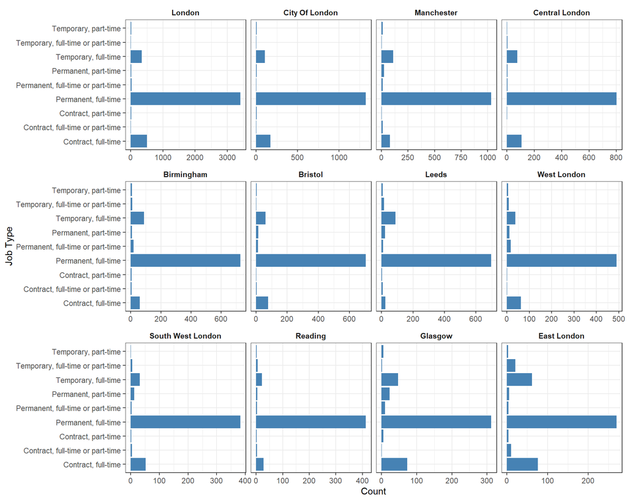

```r
torre %>%
  filter(city %in% top_city) %>% #Only the most frequent cities
  count(city, job_type) %>%
  ggplot(aes(job_type, n)) + geom_col(fill="steelblue") +
  facet_wrap(~city, scales = "free_x") + coord_flip() +
  labs(y="Count", x="Job Type") +
  theme_bw() +
  theme(strip.background = element_blank(),
        strip.text = element_text(face = "bold"))
```

Regardless of city, the most frequent job type is Permanent full-time. There are some slight differences between the counts of Temporary Jobs in certain cities. East London and Glasgow, for example, have more diversity on temporary jobs than places like Reading or West London.

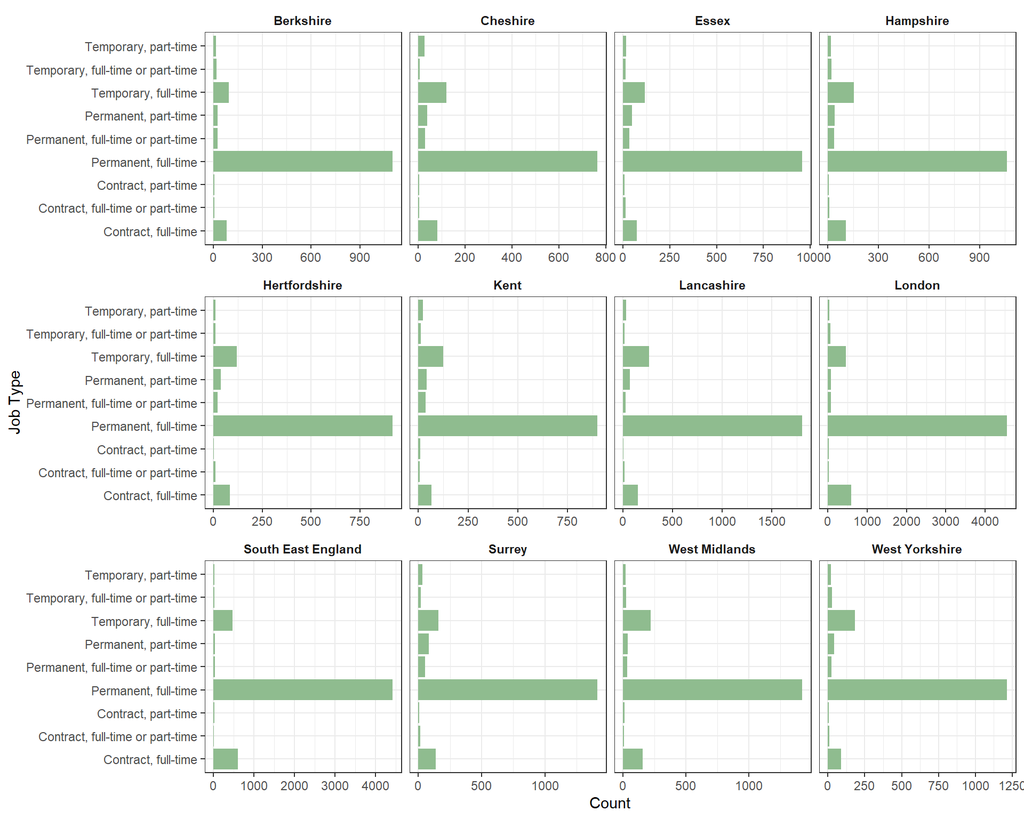

```r
top_state <- top_chars("state")

torre %>%
  filter(state %in% top_state) %>%
  count(state, job_type) %>%
  ggplot(aes(job_type, n)) + geom_col(fill="darkseagreen") +
  facet_wrap(~state, scales = "free_x") + coord_flip() +
  labs(y="Count", x="Job Type") +
  theme_bw() +
  theme(strip.background = element_blank(), strip.text = element_text(face = "bold"))
```

As above, Surrey and Kent have a different Temporary job landscape as London.

Although in all regions Permanent Full time is the dominant posting, there seems to be a shift on Temporary Jobs depending on its geographic location.

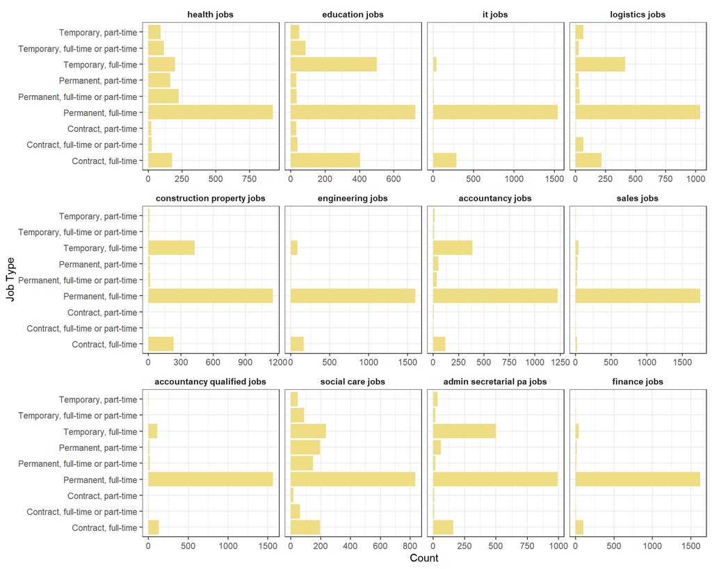

```r
top_category <- top_chars("category")

torre %>%
  filter(category %in% top_category) %>%
  count(category, job_type) %>%
  ggplot(aes(job_type, n)) + geom_col(fill="lightgoldenrod") +
  facet_wrap(~category, scales = "free_x") + coord_flip() +
  labs(y="Count", x="Job Type") +
  theme_bw() +
  theme(strip.background = element_blank(), strip.text = element_text(face = "bold"))
```

Here it is seen the biggest differences on distributions so far on `job_type`. For instance, education jobs has the highest proportion of temporary full-time jobs, while health and social care jobs have more diversity on them. The predictor `category` can become very important in the modeling process.

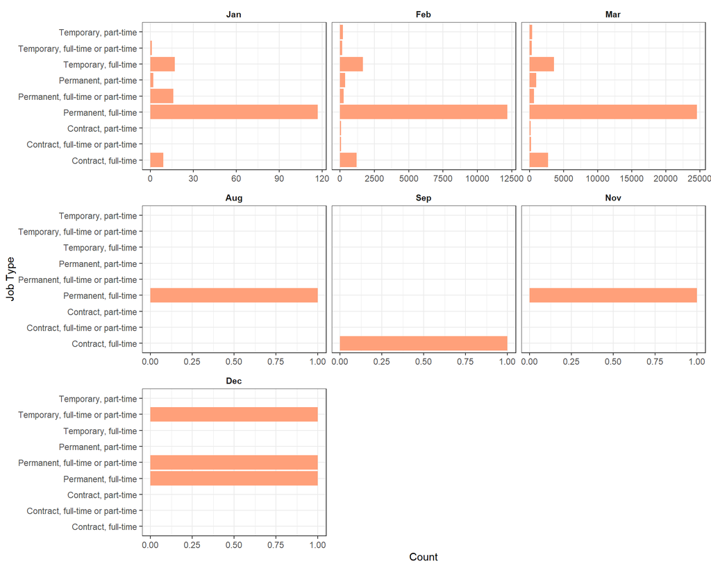

```r
torre %>%
  #filter(month<=3) %>% # There is not much data outside these months
  mutate(month=month(post_date, label = TRUE)) %>%
  count(month, job_type) %>%
  ggplot(aes(job_type, n)) + geom_col(fill = "lightsalmon") +
  facet_wrap(~month, scales = "free_x") + coord_flip() +
  labs(y="Count", x="Job Type") +
  theme_bw() +
  theme(strip.background = element_blank(), strip.text = element_text(face = "bold"))
```

Almost no data is visible for months other than January, February and March. The dataframe should contain only such months to remove non frequent data values.

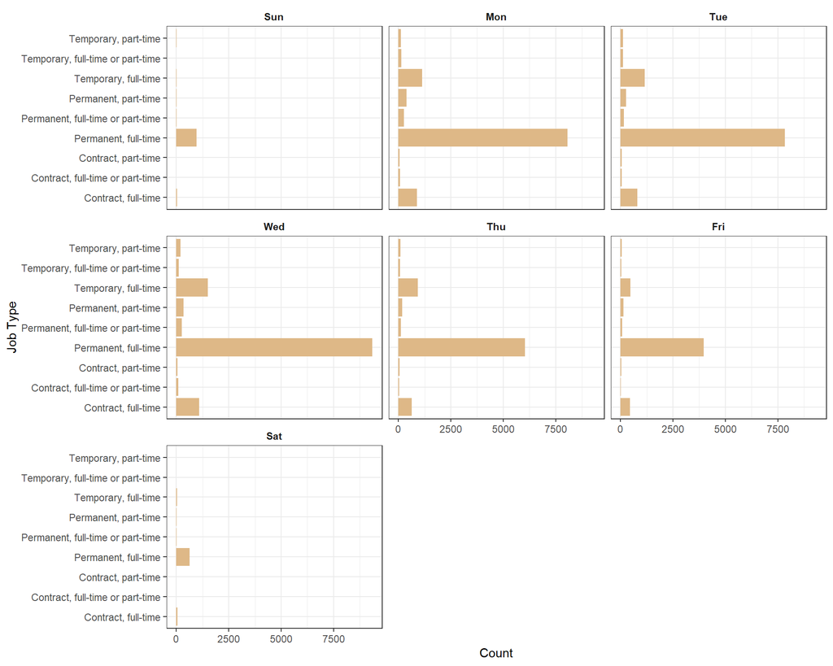

```r
torre %>%
  mutate(w=wday(post_date, label = TRUE)) %>%
  count(w, job_type) %>%
  ggplot(aes(job_type, n)) + geom_col(fill="burlywood") +
  facet_wrap(~w) + coord_flip() +
  labs(y="Count", x="Job Type") +
  theme_bw() +
  theme(strip.background = element_blank(), strip.text = element_text(face = "bold"))
```

Not surprisingly, most posting happen during working days. However, an important amount are also posted on weekends, more on Sunday than on Saturdays.

For the variable `description`, there are number of possibilities for analysis. Due to the limited amount of time, I will show the counts of the most important words by `job_type`.

```r
# Get all the words from job description and remove stop words
words_desc <- torre %>%
  select(job_type, job_description) %>%
  #group_by(job_type) %>%
  unnest_tokens(word, job_description) %>%
  anti_join(stop_words %>%
              bind_rows(tibble(word=c("2", "3", "â", "II"), lexicon="OWN")))

# Count the words by job type
count_words <- words_desc %>%
  count(job_type, word) %>%
  group_by(job_type) %>%
  top_n(20, n) %>% ungroup()
```

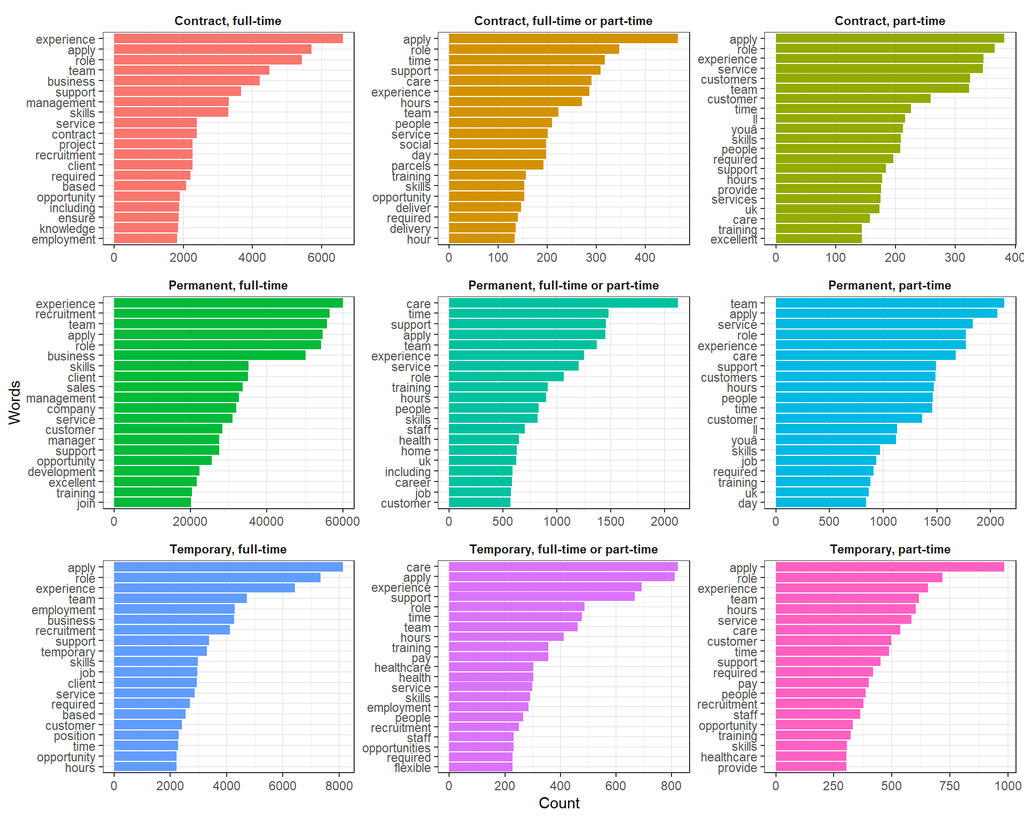

```r
count_words %>%
  ggplot(aes(reorder_within(word, n, job_type), n, fill=job_type)) + geom_col() +
  facet_wrap(~job_type, scales="free")  +
  coord_flip() + labs(x="Words", y="Count") +
  scale_x_reordered() +
  guides(fill=FALSE) +
  theme_bw() +
  theme(strip.background = element_blank(), strip.text = element_text(face = "bold"))
```

Here we can see there is definitely a difference between the language of each job type. We can extract a lot of information from this variable through techniques such as Correspondence Analysis.

As it has been shown, there is potential structure on the data that can be exploited to answer my question. However, due to limited time and computational resources, I will have to model with just a part of the predictors, primarily `city`, `state`, `category`, `weekday`, `month` and `job_description`.

## Preprocessing

I will develop 5 splits: 2 slice of the whole data for Non-Neural Network algorithms and 3 slices for a Tensorflow Neural Network.

```r
# Caret sets
set.seed(2001)
splits   <- initial_split(torre, prop = 0.7)
train_df <- training(splits)
test_df  <- testing(splits)

# Tensorflow IDs, sets will be added shortly
train_ids <- sample(1:nrow(torre), size = 0.7*nrow(torre))
dev_ids <- split(setdiff(1:nrow(torre), train_ids),c(1,2))
```

The package `recipes` is great help to construct this processing pipeline elegantly. It has several steps that will be taken sequentially.

```r
# Set up the formula
torre_rec <- recipe(job_type ~ city + state + category + weekday + month + job_description, data = torre) %>%
  # Extract features from description
  step_mutate(commas=str_count(job_description, ","), exclam=str_count(job_description, "!"),
              money=str_count(job_description, "£|$"), dash=str_count(job_description, "-"),
              colon=str_count(job_description, ":"), parenthesis=str_count(job_description, "\\(")) %>%
  # Create Embed Feature through NN
  step_embed(
    city, state, category,
    outcome = vars(job_type),
    num_terms = 5,
    hidden_units = 30,
    predictors = NULL,
    options = embed_control(
      loss = "binary_crossentropy",
      epochs = 10,
      validation_split = 0.2,
      verbose = 0
    )
  ) %>%
  # Remove Description and Zero Var cols
  step_rm(job_description) %>%
  step_zv(all_predictors()) %>%
  # Scaling
  step_center(all_predictors()) %>%
  step_scale(all_predictors()) %>%
  prep()
```

Above there is a special step that is crucial on this assignment. In `step_embed`, a set of numeric columns are developed using Neural Networks that decompose the complex string column structure into features readable for any algorithm.

After the recipe is designed, the data can be ‘baked’ on it.

```r
# Caret Baking
train_bake <- bake(torre_rec, train_df)
test_bake  <- bake(torre_rec, test_df)

# Tensorflow baking
train_deep <- bake(torre_rec, torre[train_ids,]) %>% mutate(job_type=as.numeric(job_type)-1)
eval_deep  <- bake(torre_rec, torre[dev_ids[[1]], ]) %>% mutate(job_type=as.numeric(job_type)-1)
test_deep  <- bake(torre_rec, torre[dev_ids[[2]], ]) %>% mutate(job_type=as.numeric(job_type)-1)
```

Now, let’s set up the caret training workflow. First, the learning control and the search grids for each algorithm.

```r
# Control Settings
control <- trainControl(method  = "cv", number  = 5)

# Search Grids
ridge_grid <- expand.grid(alpha  = 0,
                          lambda = 10^seq(10,-2, length = 50))

lasso_grid <- expand.grid(alpha = 1,
                          lambda = 10^seq(10,-2, length = 50))

tree_grid  <- expand.grid(maxdepth = seq(5, 30, 5))

rf_grid    <- expand.grid(mtry = seq(2, 5, 1))

knn_grid <- expand.grid(k=seq(5, 50, 5))
```

Then, the models are trained with these settings. To increase speed, it is done in parallel.

```r
# Setting up cores for parallel training
cores <- detectCores()
cl <- makePSOCKcluster(cores-2)

registerDoParallel(cl)

set.seed(2001)

# Training models
tictoc::tic()
## Ridge Regression
ridge_mod <- train(job_type ~ ., data = train_bake,
                   trControl = control, method = "glmnet",
                   tuneGrid  = ridge_grid, family = "multinomial",
                   type.multinomial = "grouped")

## Lasso Regression
lasso_mod <- train(job_type ~ ., data = train_bake,
                   trControl = control, method = "glmnet",
                   tuneGrid  = lasso_grid, family = "multinomial",
                   type.multinomial = "grouped")

## Random Forest
rf_mod    <- train(job_type ~ ., data = train_bake,
                   trControl = control, method = "rf",
                   tuneGrid  = rf_grid)

## K Nearest Neighbors
knn_mod   <- train(job_type ~ ., data = train_bake,
                   trControl = control, method = "knn",
                   tuneGrid  = knn_grid)

stopCluster(cl)
tictoc::toc()
```

For the tensorflow model, the grid search is way more extensive. On the one below, there are at least 4000 models that can be trained with these parameters. Most of the time, it is decided at random which combination gets trained. On this case, only 1% of the models possible will be evaluated.

For this, the package `tfruns` does a great job making the sample of hyperparameters and then saving the model diagnostic so the best can be trained with those settings.

```r
# Definition of the hyperparameters
runs <- tuning_run("src/nnet-grid.R",
                   flags = list(
                     nodes1 = c(32, 64, 128),
                     nodes2 = c(32, 64, 128),
                     nodes3 = c(32, 64, 128),
                     nodes4 = c(32, 64, 128),
                     reg1 = c(0.25, 0.5, 0.75),
                     reg2 = c(0.25, 0.5, 0.75),
                     lrannea1 = c(0.001, 0.01, 0.1),
                     lrannea2 = c(0.1, 0.05)
                   ),
                   sample = 0.01
)

# Best parameters are selected
best_r <- ls_runs() %>% arrange(desc(metric_val_accuracy)) %>% filter(str_detect(run_dir, "^runs/2021"))%>%
  select(starts_with("flag"), metric_accuracy, metric_val_accuracy) %>%
  head(2)
```

The best settings are then used to fit the best model found through the runs.

```r
# Makes structured data available in the keras framework
source("src/funs/df_to_dataset.R")

# Batch set up
batch_size <- 700 # nrow(train)/50 # 700
train_ds   <- df_to_dataset(train_deep, batch_size = batch_size)
eval_ds    <- df_to_dataset(eval_deep, shuffle = FALSE, batch_size = batch_size)
test_ds    <- df_to_dataset(test_deep, shuffle = FALSE, batch_size = batch_size)

spec <- feature_spec(train_ds, job_type ~ .) %>%
  step_numeric_column(all_numeric())

spec_prep <- fit(spec)

# Model structure
nn_mod <- keras_model_sequential() %>%
  layer_dense_features(dense_features(spec_prep)) %>%
  layer_dense(units = best_r$flag_nodes1[1], activation = "relu") %>%
  layer_batch_normalization() %>%
  layer_dense(units = best_r$flag_nodes2[1], activation = "relu",
              kernel_regularizer = regularizer_l2(l = best_r$flag_reg1[1])) %>%
  layer_batch_normalization() %>%
  layer_dense(units = best_r$flag_nodes3[1], activation = "relu",
              kernel_regularizer = regularizer_l2(l = best_r$flag_reg2[1])) %>%
  layer_batch_normalization() %>%
  layer_dense(units = best_r$flag_nodes4[1], activation = "relu") %>%
  layer_batch_normalization() %>%
  layer_dense(units = 9, activation = "softmax") %>%
  compile(
    loss = loss_sparse_categorical_crossentropy,
    optimizer = optimizer_adam(lr = best_r$flag_lrannea1[1]),
    metrics = "accuracy"
  )


# Training history
hist_nn <- nn_mod %>%
  fit(
    dataset_use_spec(train_ds, spec = spec_prep),
    epochs = 50,
    callbacks = list(callback_reduce_lr_on_plateau(factor = best_r$flag_lrannea2[1])),
    validation_data = dataset_use_spec(eval_ds, spec_prep),
    verbose = 2
  )
```

After the modeling is finished, the test setting can be evaluated on all the models and check which one has the lowest error. Here comes a big question, which metric should be used? For Multilabel classification, the accuracy, precision and other metrics normal in binary tasks are calculated for each level minus 1, making the evaluation process harder than it was. One that stays the same is the AUC. Although it’s not settle which metric shall be used in this task and other can be checked, for sake of simplicity only this one will be presented.

```r
# Save the predictions
pred_ridge <- predict(ridge_mod, newdata = test_bake %>% select(-job_type))
pred_lasso <- predict(lasso_mod, newdata = test_bake %>% select(-job_type))
pred_rf    <- predict(rf_mod, newdata = test_bake %>% select(-job_type))
pred_knn   <- predict(knn_mod, newdata = test_bake %>% select(-job_type))
pred_nn    <- predict_classes(nn_mod, test_deep %>% select(-job_type))

# Calculate the AUC
pred_res <- c(ridge = multiclass.roc(response=test_bake$job_type, predictor=as.numeric(pred_ridge))$auc,
              lasso = multiclass.roc(response=test_bake$job_type, predictor=as.numeric(pred_lasso))$auc,
              rf    = multiclass.roc(response=test_bake$job_type, predictor=as.numeric(pred_rf))$auc,
              knn   = multiclass.roc(response=test_bake$job_type, predictor=as.numeric(pred_knn))$auc,
              nn    = multiclass.roc(response=test_deep$job_type, predictor=as.numeric(pred_nn))$auc)

sort(pred_res, decreasing = TRUE)
```

```
##        rf       knn        nn     ridge     lasso
## 0.6564719 0.5315757 0.5275355 0.5000000 0.5000000
```

According to AUC the best model trained is the Random Forest with an AUC of 65, followed by K Nearest Neighbors.

## Final Remarks

Although an AUC of 65 is not bad for a multiclass problem, there is still a lot of room to increase it. First, there is search to be on Random Forest, K Nearest Neighbors and Neural Networks. Perhaps, those new designs might increase our metrics’ value.

Also, the description variable is full of opportunities. With more time, other features can be extracted from it such as log of odds for special keywords.

Computing power might also have helped on this task. However, I would recommend to keep searching on model designs and feature extraction as there is still a lot of possibilities to cover for them.

Feel free to check this [project’s repo](https://github.com/MadNietzsche/Torre) for all the scripts and analysis made.